# Analyzing Stress and Social Media through Reddit and Twitter

Katie Stevens, Lydia Lan, Jennifer Oh, Wesley Gu

11/14/22

## Stress Detection and Analysis in Popular Social Media Platforms

### Dynamic Paragraph

Altogether, we have used two datasets in our project. The first dataset is from a Reddit analysis of stress from 10 subreddits. Here, we can easily group our data into two categories: Not Stressed, Stressed. From there, we can identify which subreddit has the highest proportion of being stress identified. Based on our summary table, stress was the subreddit that had the highest stress percentage out of all the others, where 0.7142857 of the posts were deemed as “stressed”. Whereas, assistance had the lowest stress percentage, where 0.3181818 of the posts were deemed as “stressed”. Not stressed texts had an average negative emotion rating of 2.1249711. Stressed texts had an average negative emotion rating of 4.5195393.

From the Dreaddit dataset alone, it seems that the majority of the Reddit posts in the study showed at least some indications of stress. However, it’s also important to look at other social media platforms, so our group decided to use the Twitter Sentiment Dataset. Based on the most recent tweets from around 12:30 AM 11/10/2022, we were able to group which tweets were most postive and most negative. The most confidently postive tweet was: “We’re delighted to be hosting our first European Partner Summit in Amsterdam this month 😊🌷🚲 Looking forward to catching up with our much-loved partners, celebrating this year’s progress and looking ahead together at what’s to come in 2023 🤗 ExcitingTimes”. Whereas, the most confidently negative tweet was: ” Wow, how much supplies ahce they had, such beggers”.

### Summary Table

#### Table 1: Emotions Found in Dreddit Dataset

```
## # A tibble: 2 × 13
##   Stress Avera…¹ Media…² Avera…³ Nedia…⁴ Avera…⁵ Media…⁶ Avera…⁷ Media…⁸ Avera…⁹
##   <chr>    <dbl>   <dbl>   <dbl>   <dbl>   <dbl>   <dbl>   <dbl>   <dbl>   <dbl>
## 1 Not S…  0.109    0.109    3.50    2.94    2.12    1.73   0.484    0      0.590
## 2 Stres… -0.0144  -0.005    1.77    1.47    4.52    4.26   1.45     1.05   1.15
## # … with 3 more variables: `Median Anger` <dbl>, `Average Sadness` <dbl>,
## #   `Median Sadness` <dbl>, and abbreviated variable names
## #   ¹`Average Sentiment (-1 to 1,\n    negative indicates negative sentiment, zero is neutral)`,
## #   ²`Median Sentiment (-1 to 1,\n    negative indicates negative sentiment,\n    zero is neutral)`,
## #   ³`Average Positive Emotion`, ⁴`Nedian Negative Emotion`,
## #   ⁵`Average Negative Emotion`, ⁶`Median Negative Emotion`,
## #   ⁷`Average Anxiety`, ⁸`Median Anxiety`, ⁹`Average Anger`
```

#### Table 2: Stress Found in Subreddits

```
## # A tibble: 10 × 6
##    Subreddit        `Post Count` Stressed `Stressed Percentage` Averag…¹ Media…²
##    <chr>                   <int>    <int>                 <dbl>    <dbl>   <dbl>
##  1 almosthomeless             19       12                 0.632     33.4   25.8
##  2 anxiety                   147       85                 0.578     24.4    5.37
##  3 assistance                 66       21                 0.318     50.7   49.5
##  4 domesticviolence           72       47                 0.653     18.2    6.25
##  5 food_pantry                 6        3                 0.5       59.7   63.8
##  6 homeless                   52       18                 0.346     42.5   25.8
##  7 ptsd                      127       82                 0.646     26.9   11.2
##  8 relationships             142       60                 0.423     41.0   25.8
##  9 stress                     14       10                 0.714     17.9    3.80
## 10 survivorsofabuse           70       31                 0.443     31.6   13.7
## # … with abbreviated variable names
## #   ¹`Average Tone (numbers indicate percentiles of stress,\n    lower indicates more stress)`,
## #   ²`Median Tone (numbers indicate percentiles of stress,\n    lower indicates more stress)`
```

In this portion, I included two tables that summarize the Reddit dataset nicely. The first table contains the summary information of all the emotions detected in both “stressed” and “not stressed” posts. Posts that are deemed as stressed often have a higher value in emotions pertaining to anxiety, anger, sadness, and negativity. The average sentiment for the “not stressed” category is 0.11, and it’s -0.014 for the “stressed” category. More negative numbers correlate to higher stress, while more positive numbers indicate that there’s less stress. The second table contains the summary information of the percentage of stress detected among the posts in separate, individual subreddits. The higher the tone, the more positive and less stressful it is. Subreddits such as “stress” and “domesticviolence” are shown to contain the highest amounts of stress and negativity.

### Plots

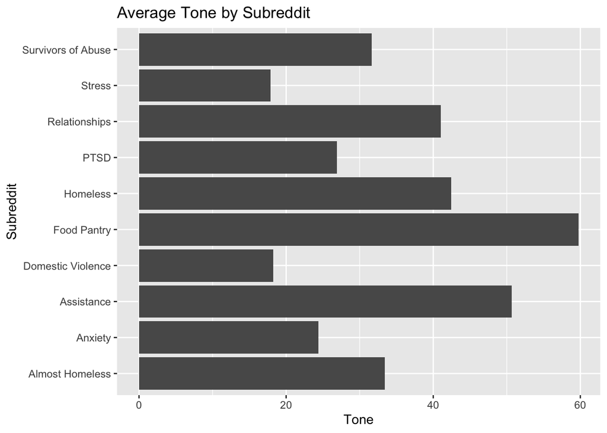

#### Plot 2

```
##   Subreddit         Reddit.Text           Stress          Model.Confidence
##  Length:715         Length:715         Length:715         Min.   :0.0000
##  Class :character   Class :character   Class :character   1st Qu.:0.6000
##  Mode  :character   Mode  :character   Mode  :character   Median :0.8000
##                                                           Mean   :0.7179
##                                                           3rd Qu.:1.0000
##                                                           Max.   :1.0000
##   Reddit.Karma         Clout        Authenticity        Tone
##  Min.   :   0.00   Min.   : 1.00   Min.   : 1.00   Min.   : 1.00
##  1st Qu.:   2.00   1st Qu.:10.34   1st Qu.:46.40   1st Qu.: 1.23
##  Median :   5.00   Median :30.24   Median :84.47   Median :16.15
##  Mean   :  24.63   Mean   :38.41   Mean   :69.92   Mean   :32.38
##  3rd Qu.:  10.00   3rd Qu.:61.58   3rd Qu.:96.94   3rd Qu.:60.40
##  Max.   :1687.00   Max.   :99.00   Max.   :99.00   Max.   :99.00
##  Positive.Emotion Negative.Emotion    Anxiety            Anger
##  Min.   : 0.000   Min.   : 0.000   Min.   : 0.0000   Min.   : 0.0000
##  1st Qu.: 1.005   1st Qu.: 1.320   1st Qu.: 0.0000   1st Qu.: 0.0000
##  Median : 2.060   Median : 2.880   Median : 0.0000   Median : 0.0000
##  Mean   : 2.607   Mean   : 3.361   Mean   : 0.9809   Mean   : 0.8803
##  3rd Qu.: 3.910   3rd Qu.: 4.920   3rd Qu.: 1.5450   3rd Qu.: 1.4700
##  Max.   :14.290   Max.   :16.670   Max.   :16.6700   Max.   :11.9000
##     Sadness           Power          Sentiment
##  Min.   :0.0000   Min.   : 0.000   Min.   :-1.00000
##  1st Qu.:0.0000   1st Qu.: 1.100   1st Qu.:-0.05618
##  Median :0.0000   Median : 2.080   Median : 0.04246
##  Mean   :0.6004   Mean   : 2.472   Mean   : 0.04534
##  3rd Qu.:1.1000   3rd Qu.: 3.520   3rd Qu.: 0.15470
##  Max.   :6.4500   Max.   :11.110   Max.   : 0.80000
```

#### Word Cloud

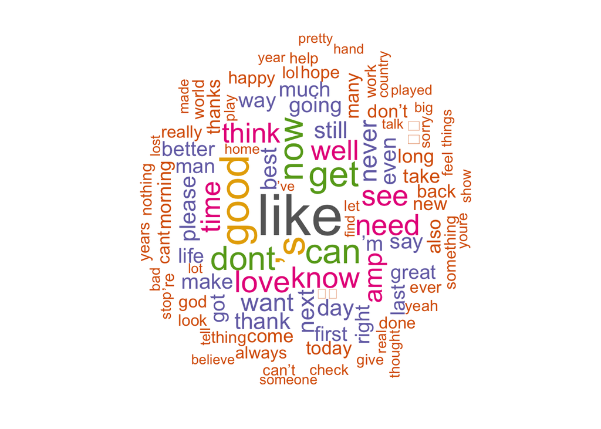

This word cloud shows the top 100 words that consistently appears in the “Twitter Sentiment Dataset”. The more that a specific word appears or is used by someone, the bigger and bolder it appears in the chart. At first glance, we see that the largest words are “like”, “good”, and “don’t”. Moreover, words that usually wouldn’t be considered commonly used, such as “love”, “happy”, “stop”, “want”, and “hope”, show that emotional feelings are regularly brought up in the tweets we’re analyzing. We see that both negative and positive connotions are present, with seemingly more positive words than negative. However, because the word cloud simply serves as a visual representation, it’s possible that there’s more negative phrases that use unique wording instead.